# Forest Fire

Our client want me to predict the burned area of forest fires using meteorological and other data.  
The data set I have contains the weather information, date, location in the northeast region of Portugal.

> Portugal is highly affected by forest fires. From 1980 to 2005, over 2.7 million ha of forest area (equivalent to the Albania land area) have been destroyed. The 2003 and 2005 fire seasons were especially dramatic, affecting 4.6% and 3.1% of the territory, with 21 and 18 human deaths.  
> -- European-Commission. Forest Fires in Europe. Technical report, Report N-4/6, 2003/2005.

```r
require(data.table) || install.packages("data.table", repos='http://cran.us.r-project.org')  # rename
require(dplyr) || install.packages("dplyr", repos='http://cran.us.r-project.org')  # data wrangling
require(ggplot2) || install.packages("ggplot2", repos='http://cran.us.r-project.org')  # visualization
require(gridExtra) || install.packages("gridExtra", repos='http://cran.us.r-project.org')  # arrange visualization
require('corrgram') || install.packages("corrgram", repos='http://cran.r-project.org')   # correlation map
require(kernlab) || install.packages("kernlab", repos='http://cran.us.r-project.org')
require(caret) || install.packages("caret", repos='http://cran.us.r-project.org')
require(e1071) || install.packages("e1071", repos='http://cran.us.r-project.org')
require(MASS) || install.packages("MASS", repos='http://cran.us.r-project.org')  # linear discriminant analysis
require(Amelia) || install.packages("Amelia", repos='http://cran.us.r-project.org')  # miss map

options(repr.plot.width=6, repr.plot.height=6)
```

TRUE

[output not shown]

TRUE

TRUE

TRUE

TRUE

TRUE

TRUE

TRUE

TRUE

TRUE

### Read in the Data Set

You can download the [Data Set](https://archive.ics.uci.edu/ml/datasets/Forest+Fires) by clicking the link.

```r
fire <- read.csv("F:/UVA/Spring 2017/StatisticalConsulting/FinalProject/forestfires.csv",
                 header = TRUE, stringsAsFactors = FALSE)
head(fire)
```

| X | Y | month | day | FFMC | DMC | DC | ISI | temp | RH | wind | rain | area |
| --- | --- | --- | --- | --- | --- | --- | --- | --- | --- | --- | --- | --- |
| 7 | 5 | mar | fri | 86.2 | 26.2 | 94.3 | 5.1 | 8.2 | 51 | 6.7 | 0.0 | 0 |
| 7 | 4 | oct | tue | 90.6 | 35.4 | 669.1 | 6.7 | 18.0 | 33 | 0.9 | 0.0 | 0 |
| 7 | 4 | oct | sat | 90.6 | 43.7 | 686.9 | 6.7 | 14.6 | 33 | 1.3 | 0.0 | 0 |
| 8 | 6 | mar | fri | 91.7 | 33.3 | 77.5 | 9.0 | 8.3 | 97 | 4.0 | 0.2 | 0 |
| 8 | 6 | mar | sun | 89.3 | 51.3 | 102.2 | 9.6 | 11.4 | 99 | 1.8 | 0.0 | 0 |
| 8 | 6 | aug | sun | 92.3 | 85.3 | 488.0 | 14.7 | 22.2 | 29 | 5.4 | 0.0 | 0 |

```r
glimpse(fire)
```

```
Observations: 517
Variables: 13
$ X     <int> 7, 7, 7, 8, 8, 8, 8, 8, 8, 7, 7, 7, 6, 6, 6, 6, 5, 8, 6, 6, 6...
$ Y     <int> 5, 4, 4, 6, 6, 6, 6, 6, 6, 5, 5, 5, 5, 5, 5, 5, 5, 5, 4, 4, 4...
$ month <chr> "mar", "oct", "oct", "mar", "mar", "aug", "aug", "aug", "sep"...
$ day   <chr> "fri", "tue", "sat", "fri", "sun", "sun", "mon", "mon", "tue"...
$ FFMC  <dbl> 86.2, 90.6, 90.6, 91.7, 89.3, 92.3, 92.3, 91.5, 91.0, 92.5, 9...
$ DMC   <dbl> 26.2, 35.4, 43.7, 33.3, 51.3, 85.3, 88.9, 145.4, 129.5, 88.0,...
$ DC    <dbl> 94.3, 669.1, 686.9, 77.5, 102.2, 488.0, 495.6, 608.2, 692.6, ...
$ ISI   <dbl> 5.1, 6.7, 6.7, 9.0, 9.6, 14.7, 8.5, 10.7, 7.0, 7.1, 7.1, 22.6...
$ temp  <dbl> 8.2, 18.0, 14.6, 8.3, 11.4, 22.2, 24.1, 8.0, 13.1, 22.8, 17.8...
$ RH    <int> 51, 33, 33, 97, 99, 29, 27, 86, 63, 40, 51, 38, 72, 42, 21, 4...
$ wind  <dbl> 6.7, 0.9, 1.3, 4.0, 1.8, 5.4, 3.1, 2.2, 5.4, 4.0, 7.2, 4.0, 6...
$ rain  <dbl> 0.0, 0.0, 0.0, 0.2, 0.0, 0.0, 0.0, 0.0, 0.0, 0.0, 0.0, 0.0, 0...
$ area  <dbl> 0, 0, 0, 0, 0, 0, 0, 0, 0, 0, 0, 0, 0, 0, 0, 0, 0, 0, 0, 0, 0...
```

```r
# Any missing value?
sapply(fire,function(x) sum(is.na(x)))
##  No missing value
```

**X**

0

**Y**

0

**month**

0

**day**

0

**FFMC**

0

**DMC**

0

**DC**

0

**ISI**

0

**temp**

0

**RH**

0

**wind**

0

**rain**

0

**area**

0

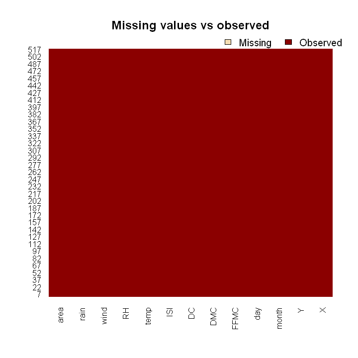

```r
missmap(fire, main = "Missing values vs observed")   # no missing value
```

```r
fire_new <- fire
```